# Final Workflow Assignment

Ziyi Zhang

3/16/2021

# Brief Introduction of Project

## Introduction and Data Collection of IV

The aim of my project is to find whether the organizational mindset can predict company-level unethical behaviors. In my project, the IV is the *organizational mindsets* of a company. Mindset is a concept comes from Carol Dweck, and she identified two different mindsets, *fixed mindset or growth mindset*. Organizational mindset is a application of this individual definition on organizations. It is like organizational culture, we can also identify different organizational mindsets between fixed and growth.

By calculating this, we collected letters to shareholders of Fortune 500 companies and let 3 trained RAs to code those letters by one Likert scale with 8 items. So we have three data-entry files created by three RAs and each of them has 8 columns indicating different items in Likert scale and 160 rows indicating different companies.

## Introduction and Data Collection of DV

In my project, the DV is the *company-levels unethical behavior*. More specifically, we use companies *accounting misstatements* as a proxy. Understanding why misstatements happen and how to detect misstatements are important to the capital market.

We employ measure of financial reporting misstatements as the dependent variable. Specifically, we use the *F-score* developed by Dechow et al. (2011) to predict material misstatements. F-score represents the likelihood of manipulation, which means a higher F-score indicates a higher probability of company’s manipulation on its financial reports. To calculate our dependent variable, we collected the financial statements of Fortune 500 from mergentonline.com website and calculated their F-scores based on Dechow’s F-score formula.

# Building Code

## Install packages

Before writing the code, we need to install required packages and library all of them. I used here, vroom, tidyverse, and readxl in my code, and I will run them now.

```r
install.packages("here")
install.packages("vroom")
install.packages("tidyverse")
install.packages("readxl")
```

```r
library(tidyverse)
library(here)
library(vroom)
library(readxl)
```

## Read IV and DV files

### Create a function to increase efficiency and reproducibility

To read all my dataset, first I created a function to read my data with or without column names. The IV files don’t have column names, but the DV file do has column names. It is messy if I typed or everytime. So I created a function with two inputs, the first is file name, and the second is whether there is a column name or not, which should be a logical input. I think this step increases the efficiency, and it also increases the reproducibility becasue I could use this function again in the future.

```r
rexcel <- function (x, y){
  stopifnot("ERROR: the second input should be logical" = is.logical(y))
  library(readxl)
  read_excel(x, col_name = y)
}
```

## Clean IV data

The order to run this project is cleaning IV data, cleaning DV data, integrating IV and DV data, then visualizing all of them ### Delete useless data The first thing I did is very simple, because we don’t need the last three survey items anymore (they have very low readabilities in pilot test), I simply took off last three columns of the first data entry file, which is the only one with those three columns.

```r
Data_entry_1 <- Data_entry_1 %>% select(1:9)
```

### Rename colunms

Then the second thing I did is renaming all IV files because they didn’t have column names before. For this part, I have tried to create a file list with file names and then make a for loop. But when I used *list.files* function, r always didn’t give me anything back, so finally I used a messy way to rename.

```r
Data_entry_1 <- Data_entry_1 %>% rename(Company_Name = '...1', Q1 = '...2', Q2 = '...3', Q3 = '...4', Q4 = '...5',
                        Q5 = '...6', Q6 = '...7', Q7 = '...8', Q8 = '...9')
Data_entry_2 <- Data_entry_2 %>% rename(Company_Name = '...1', Q1 = '...2', Q2 = '...3', Q3 = '...4', Q4 = '...5',
                                        Q5 = '...6', Q6 = '...7', Q7 = '...8', Q8 = '...9')
Data_entry_3 <- Data_entry_3 %>% rename(Company_Name = '...1', Q1 = '...2', Q2 = '...3', Q3 = '...4', Q4 = '...5',
                                        Q5 = '...6', Q6 = '...7', Q7 = '...8', Q8 = '...9')
```

### Integrate all three IV files and Add the coder column to identify different coders

If I would like to integrate all IV data into one whole file, different coders can be integrated in one column, for example, called “Coder”, so that would be easier to calculate the inter-coder agreement by grouping by different coders. So I added a Coder column to each file and then make it like the tidying format standards we talked before. In the evaluations file, different rows indicating different firms and different columns indicating different variables, including coders and eight survey items.

```r
Coder_1 <- 1
Coder_2 <- 2
Coder_3 <- 3

Data_entry_1 <- Data_entry_1 %>% add_column(Coder = Coder_1, .before = "Q1")
Data_entry_2 <- Data_entry_2 %>% add_column(Coder = Coder_2, .before = "Q1")
Data_entry_3 <- Data_entry_3 %>% add_column(Coder = Coder_3, .before = "Q1")

Evaluations <- bind_rows(Data_entry_1, Data_entry_2, Data_entry_3)
```

### Add a rank column to IV file and Take off rows end with a or b, just keep 2017’s letters

In the first column of my IV file, a, b, and c refer to letters from different years, they are 2015, 2016 and 2017, respectively. But in week 1’s pilot coding work, we coded all three years letters from 2015 to 2017, but after week 1, we decided to just keep 2017’s data. Response to Jake’s question, that is becasue we didn’t have enough RAs to code three years in the meantime. But if we just looked at one year, we can finish coding using one quarter. That’s why we just have 2017’s data in the first place, but we will definitly use three years in the future. The 2015 and 2016 data, however, currently are not helpful to the working dataset.

So I decided to separate the first column by rank and year, and then drop those letters which are not in 2017.

```r
Evaluations_cleaned <- Evaluations %>% separate(Company_Name, sep = "_", into = c("Rank","Year")) %>%
  mutate(Year = ifelse(Year == "c", 2017, NA)) %>%
  filter(!is.na(Year))
```

### Reverse 1,3,4,6,8 items and then Create a mean score at the end of columns

Untile now, we got our IV data in a cleaned format, so I called it Evaluations_cleaned. Then, we need to transform some items in the survey becasue some of statements are formed in a reversal way. So the scores of those items should be reversed.

To do this, I also created a customized function with two inputs. The first input is the data that we want to reverse, and the second input indicates the scale range we used, becasue different scale range will affect how we reverse the scores. Although I used 1 to 6 scale range in my current project, I don’t want to make it fixed. Making scale range as an input can make this function useful in the future if I had more surveys with different scales. For example, my another project used scale range from 1 to 7 and from 1 to 4.

Function is shown here.

```r
reverse <- function(a, scale_range){
  stopifnot("ERROR: the scale range should be numeric" = is.numeric(scale_range))

    limit <- scale_range + 1
    a <- limit - a

}
```

Once run this function to those columns need to be reversed, I added a column called INB indicating the mean score of implicit beliefs evaluating by eight items from the implicit belief survey.

```r
Evaluations_cleaned <- Evaluations_cleaned %>% mutate(Q1 = reverse(Q1, 6), Q3 = reverse(Q3, 6), Q4 = reverse(Q4, 6),
                               Q6 = reverse(Q6, 6), Q8 = reverse(Q8, 6),)

INB <- Evaluations_cleaned %>% select(Q1:Q8) %>% rowMeans()
Evaluations_cleaned <- Evaluations_cleaned %>% add_column(INB = INB, .after = "Q8")
```

### Final IV file: implicit belief data

Then I just kept the Rank, Coder, and INB columns to make my dataset clearer. At that time, I found that if I used a wider format, it would be easier to compare the scores between different Coders and also calculate the mean score among coders.

So, I changed my dataset to a wider format and calculated means among coders, and then sort all my data by the rank of companies.

```r
INB_Data <- Evaluations_cleaned %>% select(Rank, Coder, INB)
INB_Data <- INB_Data %>% pivot_wider(names_from = "Coder", values_from = "INB")
Mean_INB <- INB_Data %>% select(-Rank) %>% rowMeans(na.rm = T)
INB_Data <- INB_Data %>% add_column(Mean_INB = Mean_INB, .after = "Rank") %>% select(Rank, Mean_INB)


INB_Data <- INB_Data %>% transform(Rank = as.numeric(Rank),
          Mean_INB = as.numeric(Mean_INB))


INB_Data <- INB_Data [order( INB_Data[,1] ),]
```

## Clean DV data

There is no much thing to do with the DV file, because we downloaded the financial reports of all companies from mergentonline.com website, and then did math based on the equations provided by Dechow 2011. This data is more like an archival dataset, except for the F-scores in different years, which we are calculated by inserting the formula in excel. And we will update this dataset every time we get the financial reports of a new year.

What I did with my DV file are just I kept the rank and 2018 F scores, and ordered them still by the rank. Why 2018 F scores? Becasue we want to know whether the organizational mindset could **predict** the unethical behavior, so the IV is from 2017 and the DV is from 2018.

```r
F_scores <- F_scores %>% select(`2017 Rank`, `2018 F`)
F_scores <- F_scores [order( F_scores[,1] ),]
```

## Integrate IV and DV files in one large file

Then I integrated IV and DV by using *left_join* function, in order to make it easier to plot or run regression in the future.

Becasue the F scores are from Fortune 1000 but INB scores are only coded in Fortune 500. *left_join* function is pretty useful because it could automatically help you combine two dataset based on the same **Rank** column.

```r
F_scores <- F_scores %>% rename(Rank = '2017 Rank')
Compiled_Data <- left_join(INB_Data,F_scores)
Compiled_Data <- Compiled_Data %>% drop_na()
```

## Plotting

### Create boxplots for both two variables to see whether there is any outlier

Once we get our data, it is very important to see whether there is any outlier. But going through all the data is time-consuming, so I plotted them by boxplot, which is pretty easy for us to spot outliers.

Box plot for IV data.

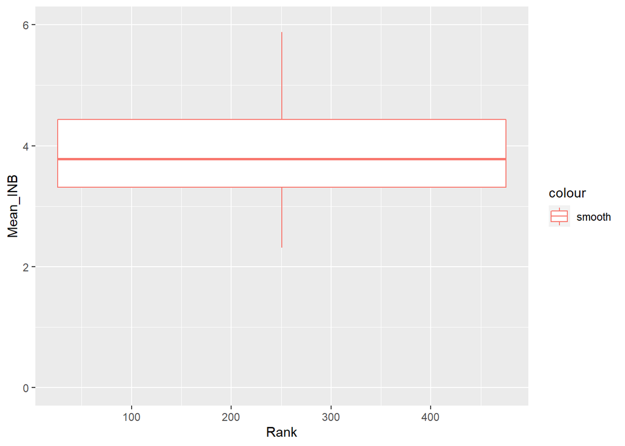

```r
Compiled_Data %>% ggplot(aes(x = Rank, colour = "smooth", y = Mean_INB)) +
  geom_boxplot() +
  ylim(0, 6)
```

Box plot for DV data.

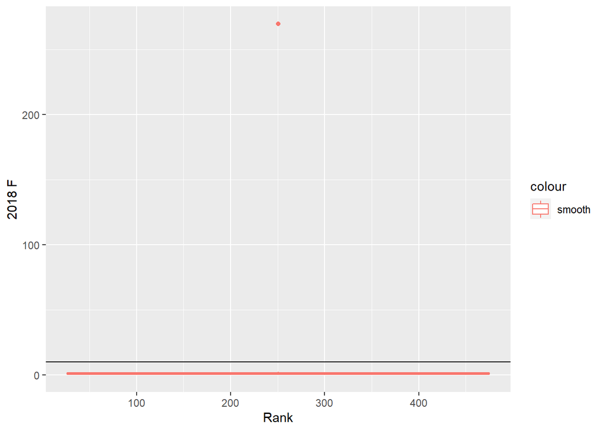

```r
Compiled_Data %>% ggplot(aes(x = Rank, colour = "smooth", y = `2018 F`)) +
  geom_hline(yintercept = 10) +
  geom_boxplot()
```

### Remove outliers

Based on the above step, we can see there is an outlier in 2018 F, and it reached more than 200, where as others are lower than 10. So we removed this outlier.

```r
Compiled_Data <- Compiled_Data %>% mutate(`2018 F` = ifelse(`2018 F` > 100, NA, `2018 F`)) %>% drop_na()
```

### Create scatter plot with two variables

The final step of my current project is creating a scatter plot with two variables to see whether there is any relationship.

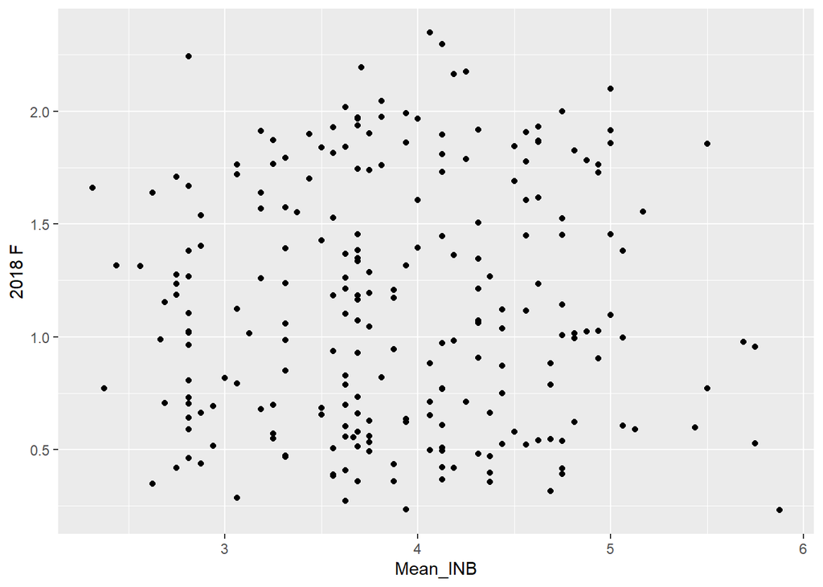

```r
Compiled_Data %>% ggplot(aes(x = Mean_INB, y = `2018 F`)) + geom_point()
```

# Conclusion

The above are all codes and analysis I current have. I think overall using R definitely increases the fidelity of my data analysis. Because at the past, when I used those windows listings and copying/pasting, human errors are very common to see. I have the same analysis by using SPSS before (at the middle of this quarter), and when I using SPSS, I definitely messed myself when I combined those scores with different ranks. I need to check one by one in case I matched wrongly. However, R can automatically do this, and I can believe computer rather than myself, so I feel the fidelity of my analysis increases.

And for reproducibility, I added customized functions this time, so it could definitely help me reuse those functions even if I am working on different dataset in the future. Also, for this current project, R comments and github can help me memory what I did for each step, so reproducibility has been increased. Recall the SPSS thing, I need to memorize all steps by myself. And it is very easy to mix all things up.

The last is efficiency. Following the memory things, when I used SPSS, if I didn’t do the whole work in the same day, it is very inefficient, because I need to almost re-do the whole work from the beginning because I lost where I were. However, when working with R, I think all my comments are useful, at least for myself, even if I didn’t work at the same day, I can recall quickly what happened last time. Also, a lot of functions in **tidyverse** is helpful, that saves me much time.

However, I think I still need to improve in the following fields. The first is how to make my codes more reader-friendly. Although currently I feel I can read anything easily, that doesn’t mean others have the same feelings. So I need to make my codes more organized in the future, also with detailed comments, and use more for loop to aviod repeated things. The second shortcoming is that I am still not very familiar with how to make my graphs beautiful and easy to deliver information. I think I need more practices on this part, after all practice is the best learning method. The last thing is not about the code, but more about my academy. I think I need to enhance the underlying mechanisms and related literature about the project I am working with. Knowing more can help me be clearer with what kind of data I would expect, and which test I would apply. If I could have a clearer goal before I analyze my data, I think it would be more efficient to write codes.

And last, thanks, John and Jake! I am really enjoyed in your teaching and tutorials! I learned a lot this quarter from both of you. And I hope both of you could have a nice break and best wishes on everything!